# Data Visualization Workshop: Activity 1

## Part e

Now run this code and comment on what it does.

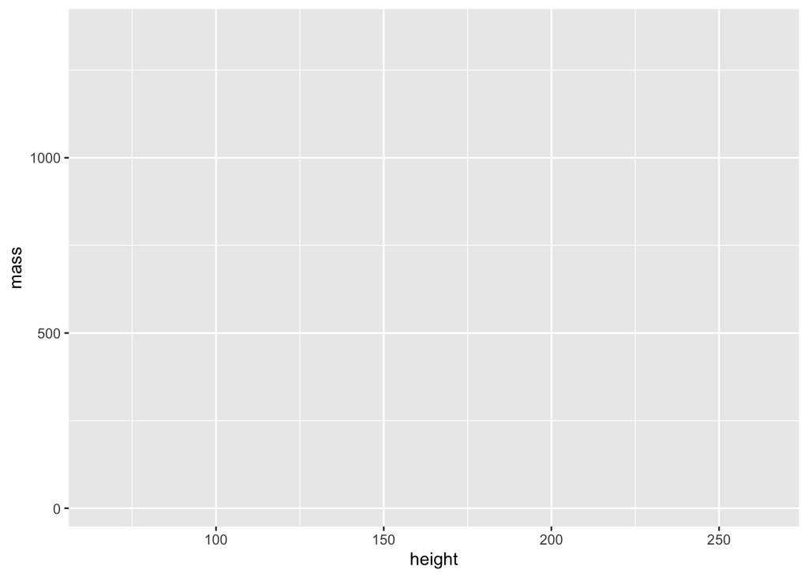

```r
ggplot(starwars, aes(x = height, y = mass))
```

This put the x-axis and the y-axis on the plot. The y-axis contains the mass info.

## Part f

Now run this code and comment on what it does.

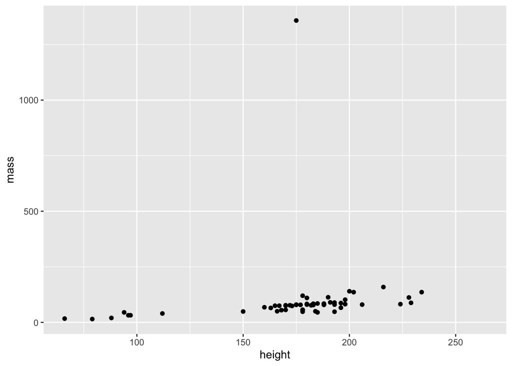

```r
ggplot(starwars, aes(x = height, y = mass)) +
  geom_point()
```

This creates the scatter plot! The x and y axes are set up and points were added to the plot.

## Part g

Hurray! We’ve made our first ggplot! However, there is one very obvious outlier. The outlier is from row 16. Remove row 16 and save the new data frame as `starwars2`. Remember you can remove a point by using brackets `[]` and putting a negative number in there.

```r
starwars2 <- starwars[-16, ]
```

## Part h

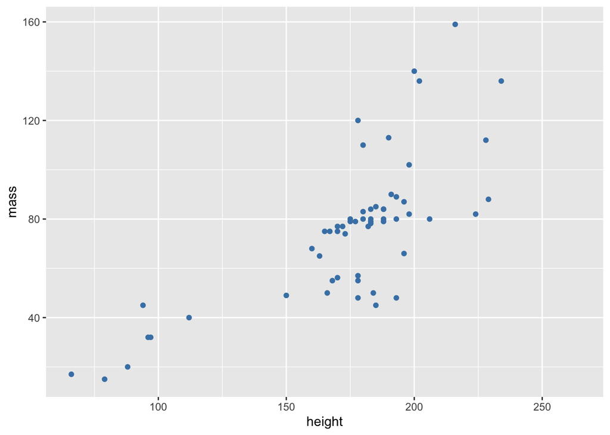

```r
ggplot(starwars2, aes(x = height, y = mass)) +
  geom_point(color = "steelblue") # Put your favorite color between the quotes.
```

## Part i

Adding onto this, let’s change the shape. You can put numbers in the shape argument. Experiment with a few of these and then choose one you like (that is not a filled circle).

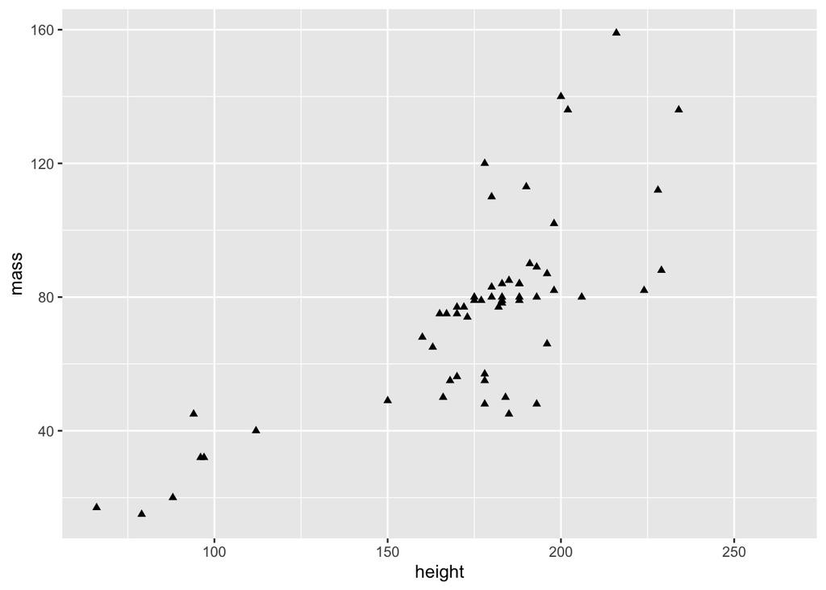

```r
ggplot(starwars2, aes(x = height, y = mass)) +
  geom_point(shape = 17) # Put a number or a keyboard symbol (in quotes) after the =
```

## Part j

Let’s change the x and y labels now. For the x-axis, change the label to “Height (cm)” and change the y-axis label to “Mass (kg)”

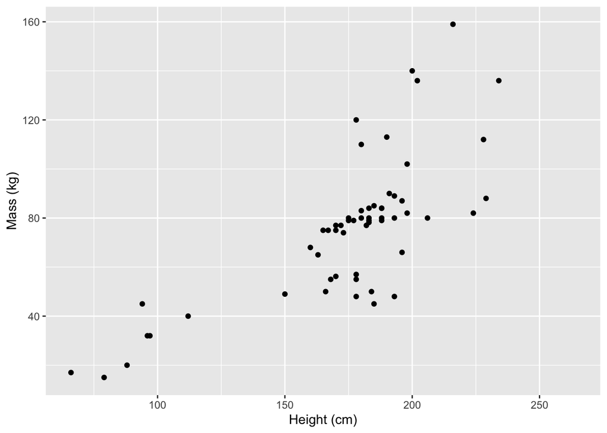

```r
ggplot(starwars2, aes(x = height, y = mass)) +
  geom_point() +
  labs(x = "Height (cm)",
       y = "Mass (kg)") # Change the x and y axis labels
```

## Part k

Now copy and paste the code from part j and add a title. You can do this by either putting `title =` in the `labs()` function or adding on the `ggtitle()` function.

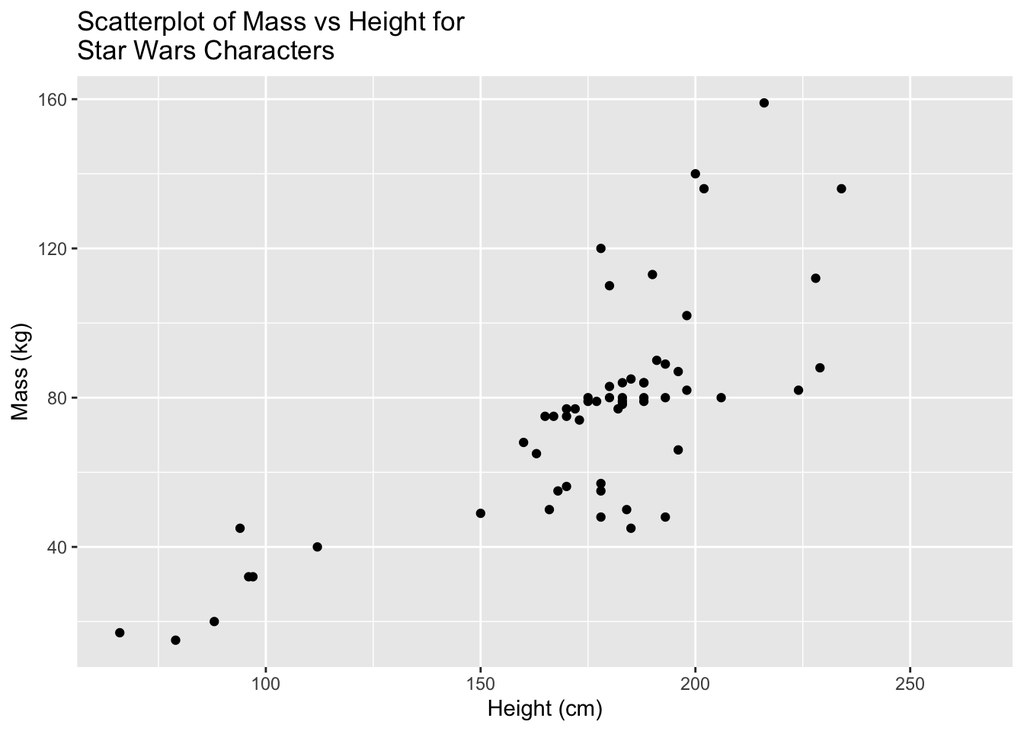

```r
ggplot(starwars2, aes(x = height, y = mass)) +
  geom_point() +
  labs(x = "Height (cm)",
       y = "Mass (kg)",
       title = "Scatterplot of Mass vs Height for\nStar Wars Characters")
```

## Part l

It is time to change the font size. In the follow code, copy and paste the code from part k so that it has the proper labels and title. Then, the way this is set up, the text size for the axis labels will be increased to size 14. Change also the text size for the title to size 18.

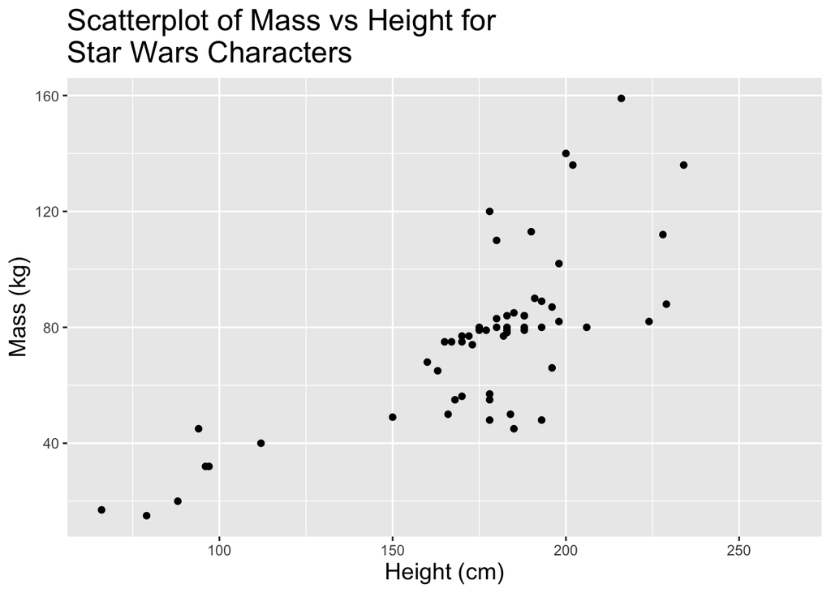

```r
ggplot(starwars2, aes(x = height, y = mass)) +
  geom_point() +
  labs(x = "Height (cm)",
       y = "Mass (kg)",
       title = "Scatterplot of Mass vs Height for\nStar Wars Characters") +
  # Put labs() function here. Put a + after it
  #   so the theme function gets added on
  theme(axis.title = element_text(size = 14),
        plot.title = element_text(size = 18))
```

## Part m

Finally, copy and paste your plot from part l. Go ahead and add the line of best fit to this plot with geom_smooth(method = “lm”). By default, confidence interval bands will also be shown. You can remove them using se = FALSE. Feel free to change the color of the line as well.

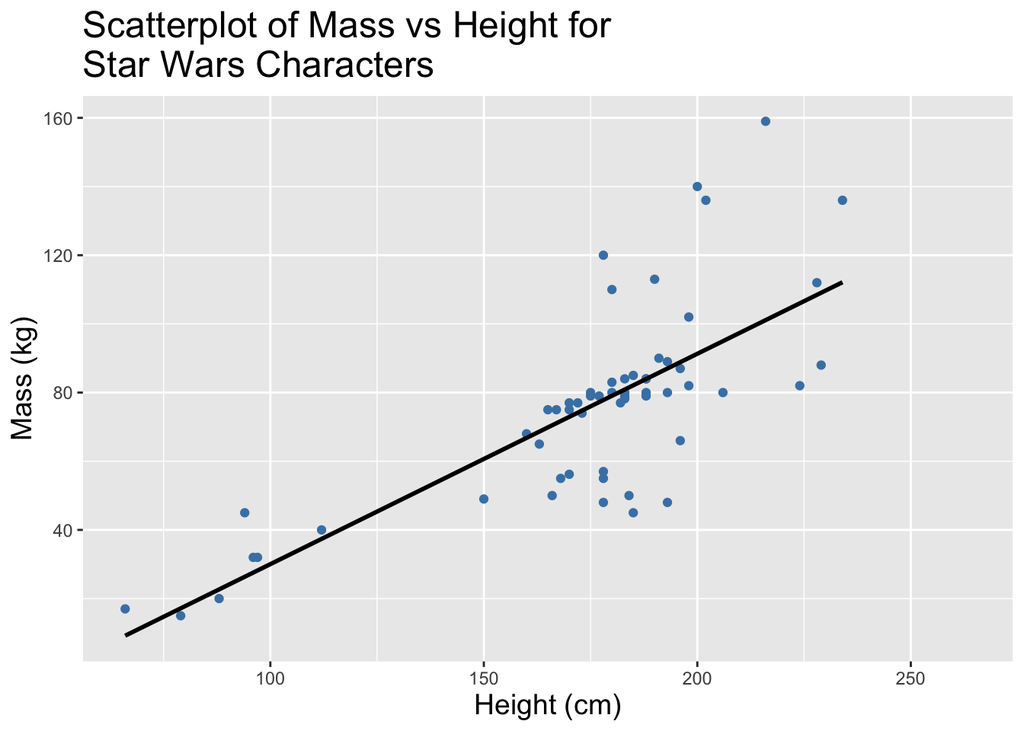

```r
ggplot(starwars2, aes(x = height, y = mass)) +
  geom_point(color = "steelblue") +
  labs(x = "Height (cm)",
       y = "Mass (kg)",
       title = "Scatterplot of Mass vs Height for\nStar Wars Characters") +
  theme(axis.title = element_text(size = 14),
        plot.title = element_text(size = 18)) +
  geom_smooth(method = "lm", formula = "y ~ x", se = FALSE, color = "black")
```